# Test run

Updates

1. Set the methods
2. Estimate the p-value for every edge in every method
3. How to evaluate performance of the methods

## Set the methods

1. Total effects from MR
2. Total effects from correlations
3. Network deconvolution of MR matrix
4. Network deconvolution of correlation matrix
5. Network deconvolution (with normalisation) of correlation matrix
- Normalisation is not possible for the MR matrix because it often has complex eigenvalues.
- Inversion of the MR matrix is possible using `corpcor::pseudoinverse` - this should solve problem of larger matrices

## Estimate p-values

For each of the methods we have a matrix of effect estimates. We would also like to have the standard errors and p-values for each of these effect estimates.

For (1) the p-value is obtained directly from 2SLS

For (2) the standard error of each correlation coefficient is

$r_{se} = \sqrt{\frac{1-r^2}{n-2}}$

For (3-5) we can use parametric bootstraps. Following procedure:

1. Sample MR matrix or correlation matrix
2. Perform ND method and save result
3. Repeat from (1) 1000 times
4. Get the distribution of values for each edge - that is the SE
5. Get p-value from true beta and bootstrapped SE

## Evaluate performance

Once we have an effects matrix, SE matrix and p-value matrix for each method, we can evaluate against the truth. For MR methods the truth is the adjacency matrix. For the correlation matrix the truth is the normalise adjacency matrix - multiply each element by `sd(x)/sd(y)` - translates the beta estimates onto the correlation scale so they will be bound between -1 and 1.

1. **Accuracy** - Evaluate the minimising of bias of the effect estimates - correlation of the estimates against the true values. Similar as MSE but comparable across methods.
2. **Edge detection** - As p-value threshold goes down, what happens to the specificity and sensitivity of the method for detecting an edge is non-zero? For symmetrical matrix just use the lower triangle. For asymmetrical matrix allow it to detect in either the lower or upper triangle.
3. **Edge orientation** - Does it detect the edge in the right direction? Similar to (2), use p-values as predictor

## Example 1

```r
source("../scripts/function_lib.R")
```

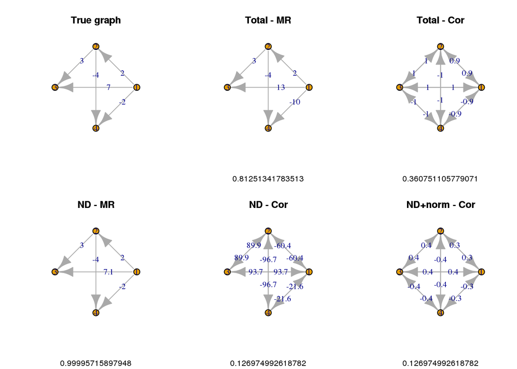

[output not shown]

```r
dat <- init_data(500000, 4, 0.1)
dat <- make_edge(1,2,2, dat)
dat <- make_edge(2,3,3, dat)
dat <- make_edge(1,3,7, dat)
dat <- make_edge(1,4,-2, dat)
dat <- make_edge(2,4,-4, dat)
dat <- normalise_r(dat)
single_test(dat, prRes=TRUE)
```

## Example 2

Similar to large simulation setup

[figure not shown]

```r
param <- expand.grid(
  nodes = c(10),
  samples = c(1000),
  sp = 0.5,
  conf = 0.1,
  pl = 0.1
)
i <- 1
# Static parameters
iter=10
edges=0
cycles=0
cycle_size=0
broke=FALSE

out <- do_test(iter, param[i, ]$nodes, param[i, ]$samples, edges, cycles, cycle_size, edgeset=param[i, ]$nodes, broken=broke, sparsity=param[i, ]$sp, cf=param[i, ]$conf, pl=param[i, ]$pl)
plot_Data(out)
```